# O2G Supply-Demand MAP Fit Report

Navigation

Section Guide

Current report structure

## Report Metadata

**Fit result:** seed30  
**Generated at:** 2026-05-21 16:26:56 EDT

## 1. Fit Summary

| Metric | Value |
| --- | --- |
| fit_mode | fit_joint |
| optimizer_method | DEoptim_parallel_plus_LBFGSB_serial |
| objective | 10.704 |
| objective_invivo | 5.832 |
| objective_invitro | 4.872 |
| joint_weight_invivo | 1 |
| joint_weight_invitro | 1 |
| joint_invitro_growth_weight | 1 |
| joint_invitro_ploidy_weight | 1 |
| joint_invitro_flow_weight | 1 |
| n_cores_requested | 22 |
| n_cores_used | 22 |
| n_parameters | 27 |

## 2. Parameters

### Fitted Parameters

#### Shared Parameters

| parameter | parameter_description | shared_value | in_vivo_value | in_vitro_value | value_difference |
| --- | --- | --- | --- | --- | --- |
| lam_max | maximum division rate lam_max in day^-1 | 0.510 | 0.510 | 0.510 | 0 |
| p_mis_base | baseline per-chromosome missegregation probability | 1.180e-05 | 1.180e-05 | 1.180e-05 | 0 |
| p_misseg | stress-linked missegregation amplification scale | 0.354 | 0.354 | 0.354 | 0 |
| k_o_mis | half-saturation scale for death-linked missegregation amplification in day^-1 | 1.057e-04 | 1.057e-04 | 1.057e-04 | 0 |
| buffer_smax | maximum per-copy survival factor for symmetric buffering missegregation survival | 0.829 | 0.829 | 0.829 | 0 |
| buffer_beta | ploidy-buffering strength for symmetric missegregation survival | 0.998 | 0.998 | 0.998 | 0 |
| buffer_n_exp | ploidy-buffering exponent for symmetric missegregation survival | 8.823 | 8.823 | 8.823 | 0 |
| alpha_o2 | soft oxygen-mediated high-ploidy growth penalty strength | 0.774 | 0.774 | 0.774 | 0 |
| gamma_growth | exponent for the soft oxygen-mediated ploidy growth penalty | 3.152 | 3.152 | 3.152 | 0 |
| mu_hp | soft thresholded high-ploidy hypoxia death strength in day^-1 | 0.001 | 0.001 | 0.001 | 0 |
| gamma_mu | exponent for high-ploidy hypoxia death above diploid reference | 2.673 | 2.673 | 2.673 | 0 |
| O2_crit | Hill critical oxygen scale for the oxygen-response weight | 0.213 | 0.213 | 0.213 | 0 |
| n_O | Hill exponent for the oxygen-response weight | 2.751 | 2.751 | 2.751 | 0 |
| p_wgd | constant per-division whole-genome doubling probability | 0.001 | 0.001 | 0.001 | 0 |

#### In Vivo-Only Fitted Parameters

| parameter | parameter_description | value |
| --- | --- | --- |
| o2_S0 | supply-demand oxygen baseline S0 in percent O2 | 4.405 |
| kappa_O | oxygen drop coefficient in the logarithmic O2 target model | 1.148 |
| eta_o2 | ploidy-weighted oxygen demand exponent | 1.188 |
| rho_2N | 2N cell density in cells per mm^3 | 89443.508 |
| qc | additive glucose/resource stress multiplier; qc=1 gives oxygen-only stress and qc=10 gives up to ten-fold co-limitation stress | 8.147 |
| k_clear | true dead-cell clearance rate in day^-1 | 1.068e-04 |
| sigma_burden | burden log-normal observation SD | 0.600 |

#### In Vitro-Only Fitted Parameters

| parameter | parameter_description | value |
| --- | --- | --- |
| sigma_growth | shared standard deviation of growth-rate observations in the in vitro likelihood | 0.660 |
| sigma_kary | shared standard deviation of chromosome-count observation error used to smooth the model-predicted N distribution before evaluating the in vitro likelihood | 0.073 |
| init_mean_2N | initial 2N-cohort Gaussian chromosome-count mean from early normoxic karyotypes | 45.725 |
| init_sd_2N | initial 2N-cohort Gaussian chromosome-count SD from early normoxic karyotypes | 2.979 |
| init_mean_4N | initial 4N-cohort Gaussian chromosome-count mean from early normoxic karyotypes | 83.701 |
| init_sd_4N | initial 4N-cohort Gaussian chromosome-count SD from early normoxic karyotypes | 5.673 |

### Fixed Parameters

#### In Vivo-Only Fixed Parameters

| parameter | parameter_description | value |
| --- | --- | --- |
| o2_min |  | 0 |
| tau_O2 | oxygen relaxation time constant when fit_tau_O2 is enabled | 0.100 |
| c_vol_2N_eff_mm3 |  | 1.118e-05 |
| ratio_4N_2N |  | 1 |
| alpha | treatment-effect scale active only when fit_treatment is TRUE | 0 |
| gamma | treatment-effect exponent active only when fit_treatment is TRUE | 1 |

#### In Vitro-Only Fixed Parameters

| parameter | parameter_description | value |
| --- | --- | --- |
| o2_S0 | supply-demand oxygen baseline S0 in percent O2 | 3.500 |
| kappa_O | oxygen drop coefficient in the logarithmic O2 target model | 0.500 |
| eta_o2 | ploidy-weighted oxygen demand exponent | 1.200 |
| rho_2N | 2N cell density in cells per mm^3 | 56000 |
| beta_size | ploidy-to-volume scaling exponent for the burden observation model | 0.350 |
| k_clear | true dead-cell clearance rate in day^-1 | 1.000e-04 |
| sigma_burden | burden log-normal observation SD | 0.200 |
| tau_O2 | oxygen relaxation time constant when fit_tau_O2 is enabled | 0.100 |
| alpha | treatment-effect scale active only when fit_treatment is TRUE | 1.000e-04 |
| gamma | treatment-effect exponent active only when fit_treatment is TRUE | 1 |
| o2_S0_upper_bound |  | 21 |
| o2_min |  | 0 |
| o2_Nref |  | 1000000 |

## 3. Figures

### 3.1 In Vivo

#### 3.1.1 Burden

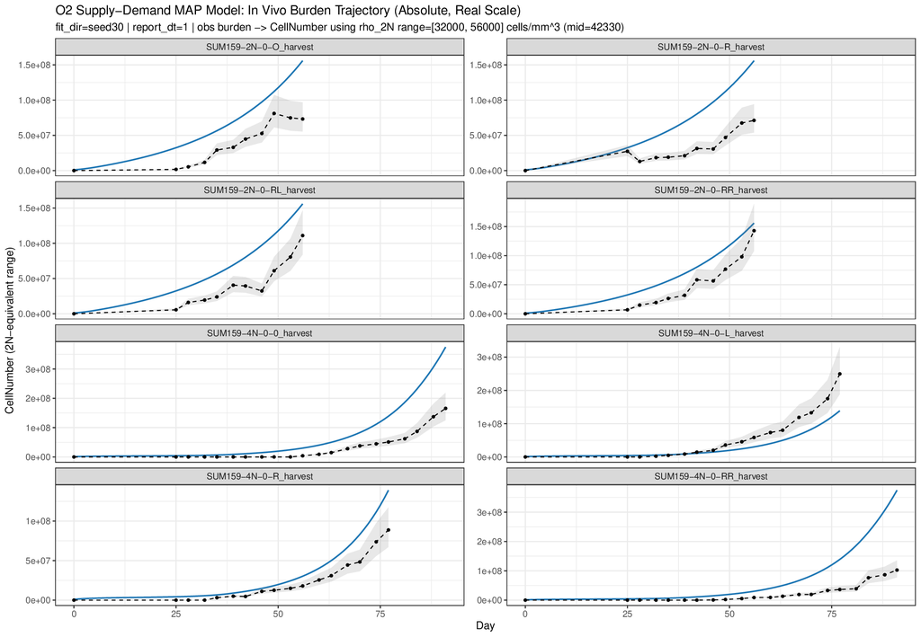

**Figure 3.1.1.1 Burden Trend Absolute (Real Scale)**

Absolute tumor burden shown on the real scale across observation times.

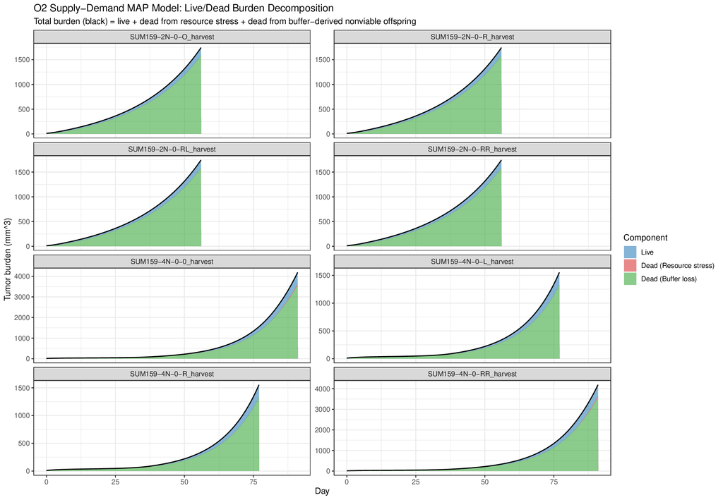

**Figure 3.1.1.2 Burden Live/Dead Decomposition**

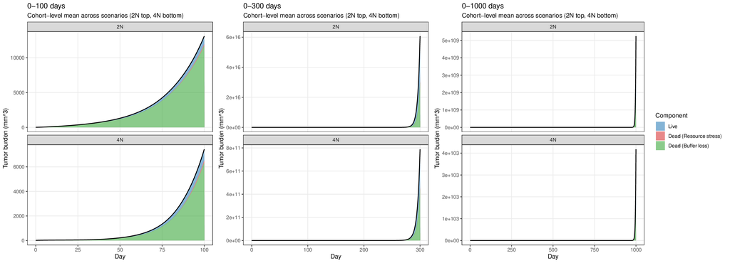

**Figure 3.1.1.3 Predicted Burden Live/Dead Decomposition (0-100/300/1000 day)**

Forward simulations from day 0 to 100, 300, and 1000 showing the predicted live/resource stress/buffer burden decomposition with a shared component legend.

#### 3.1.2 Ploidy

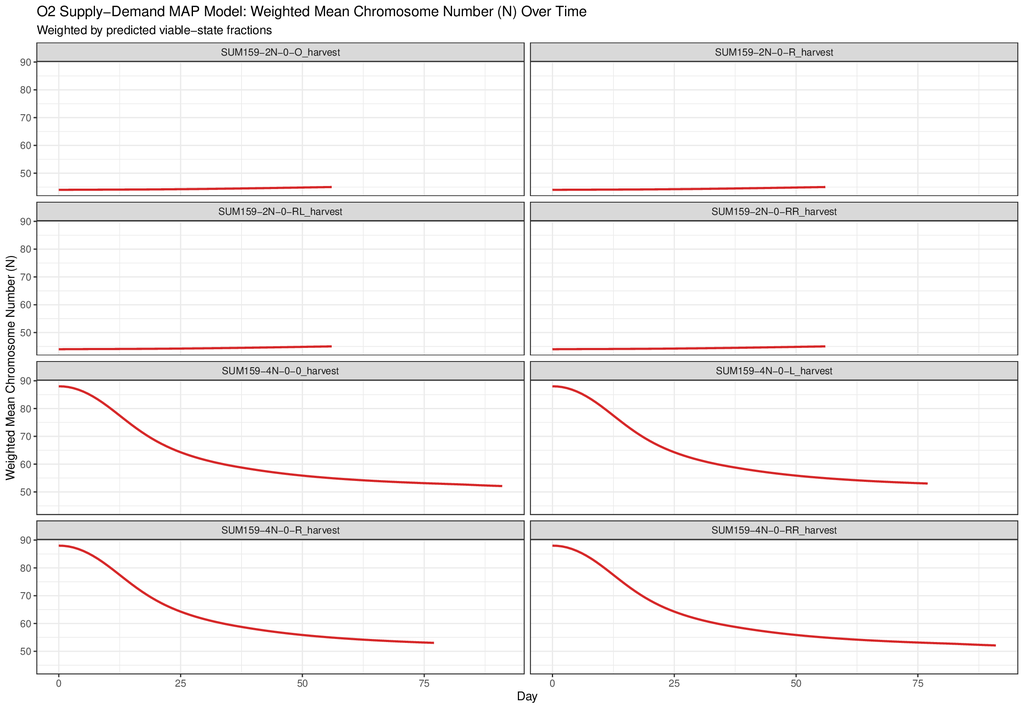

**Figure 3.1.2.1 Weighted Mean Ploidy Over Time**

Weighted mean chromosome-state trajectory over time under the fitted model.

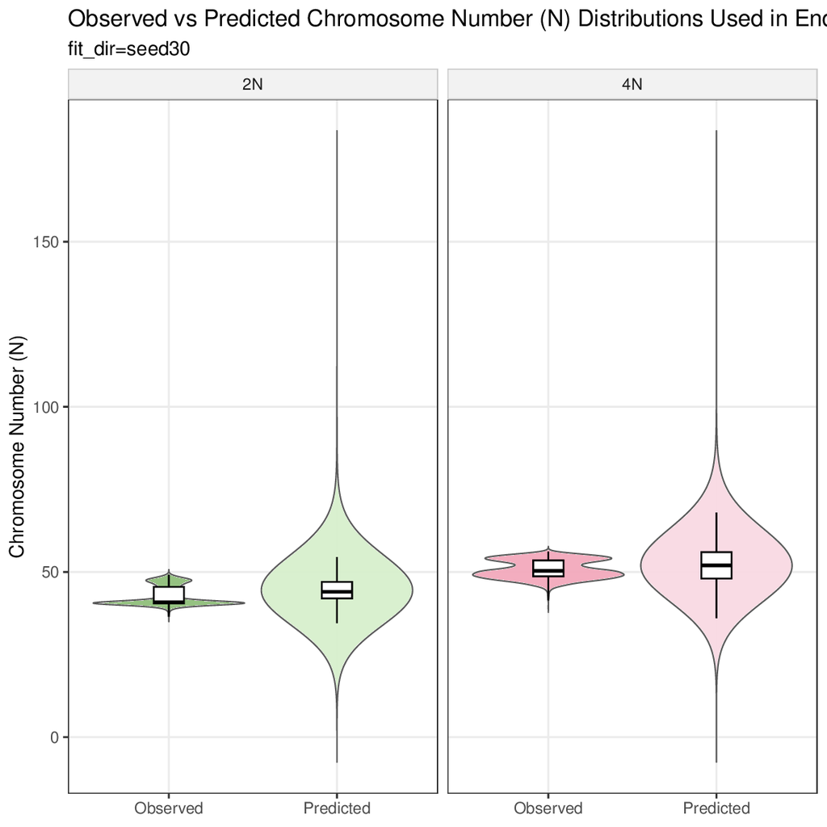

**Figure 3.1.2.2 Terminal Ploidy Observed vs Predicted**

Observed and predicted terminal ploidy or chromosome-number distributions at harvest.

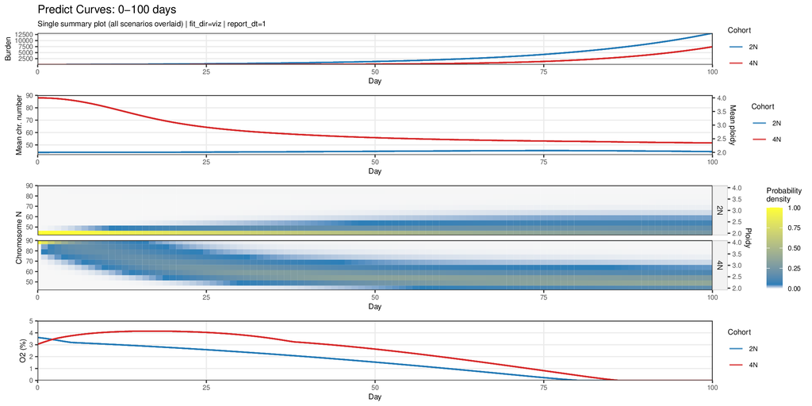

**Figure 3.1.2.3 Predicted Curves (0-100 day)**

Forward simulation from day 0 to 100 summarizing predicted burden, ploidy, and O2 trajectories.

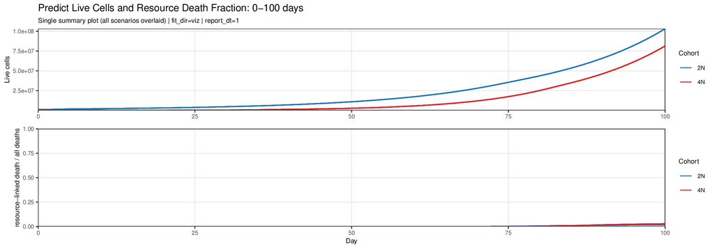

**Figure 3.1.2.4 Predicted Live Cells and Resource Death Fraction (0-100 day)**

Forward simulation from day 0 to 100 showing predicted live cells and the resource stress death fraction among all deaths.

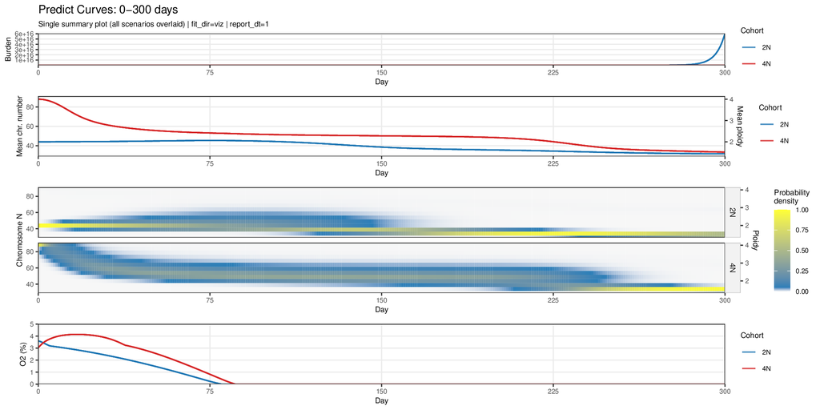

**Figure 3.1.2.5 Predicted Curves (0-300 day)**

Forward simulation from day 0 to 300 summarizing predicted burden, ploidy, and O2 trajectories.

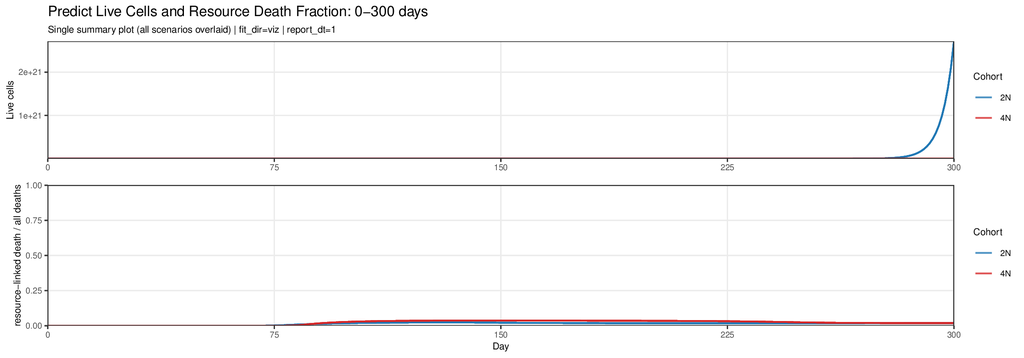

**Figure 3.1.2.6 Predicted Live Cells and Resource Death Fraction (0-300 day)**

Forward simulation from day 0 to 300 showing predicted live cells and the resource stress death fraction among all deaths.

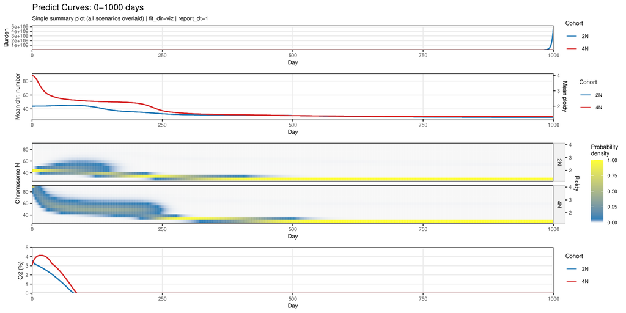

**Figure 3.1.2.7 Predicted Curves (0-1000 day)**

Forward simulation from day 0 to 1000 summarizing predicted burden, ploidy, and O2 trajectories.

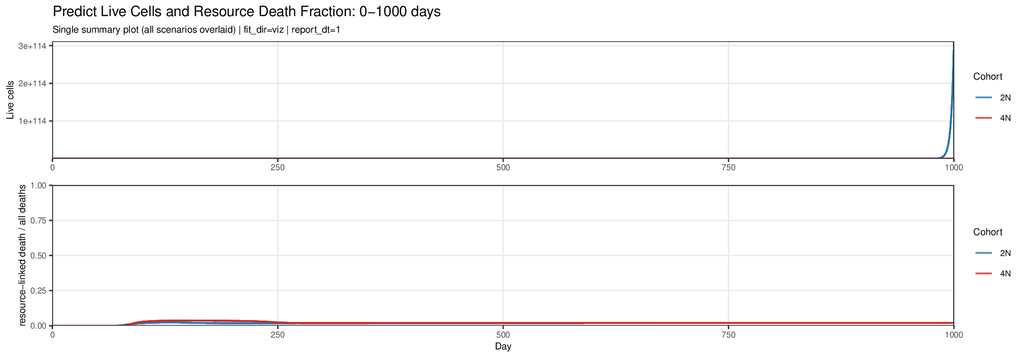

**Figure 3.1.2.8 Predicted Live Cells and Resource Death Fraction (0-1000 day)**

Forward simulation from day 0 to 1000 showing predicted live cells and the resource stress death fraction among all deaths.

#### 3.1.3 Oxygen / O2

##### 3.1.3.1 O2 Dynamics

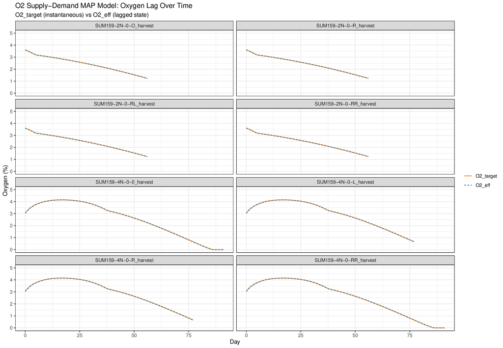

**Figure 3.1.3.1.1 O2 Target vs Effective Timecourse**

Timecourse comparison between the oxygen target and the lagged effective oxygen state used by the model.

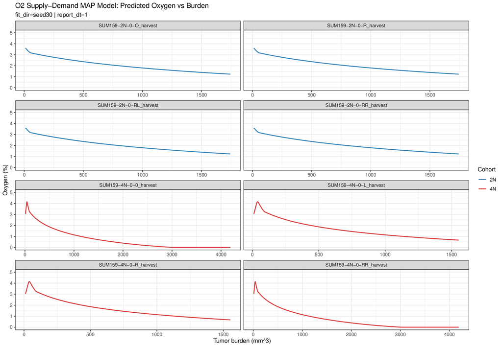

**Figure 3.1.3.1.2 Predicted Burden vs O2**

Forward-simulation burden trajectories plotted against the effective oxygen state.

##### 3.1.3.2 MS-Linked Viability and Death Relationships

Missegregation-linked viability, nonviable daughter production, and death-rate relationships.

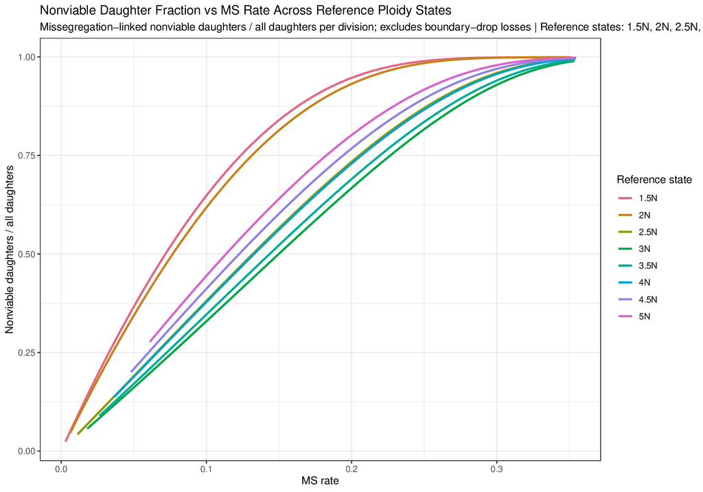

**Figure 3.1.3.2.1 Nonviable Daughter Fraction vs MS Rate**

Per-division fraction of daughter cells that are nonviable because of missegregation-linked loss, shown against missegregation rate.

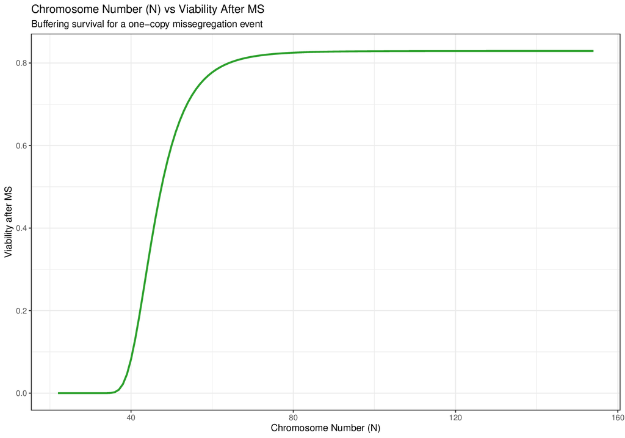

**Figure 3.1.3.2.2 Ploidy vs Viability After MS**

Viability modifier after a one-copy-loss missegregation event across the ploidy grid.

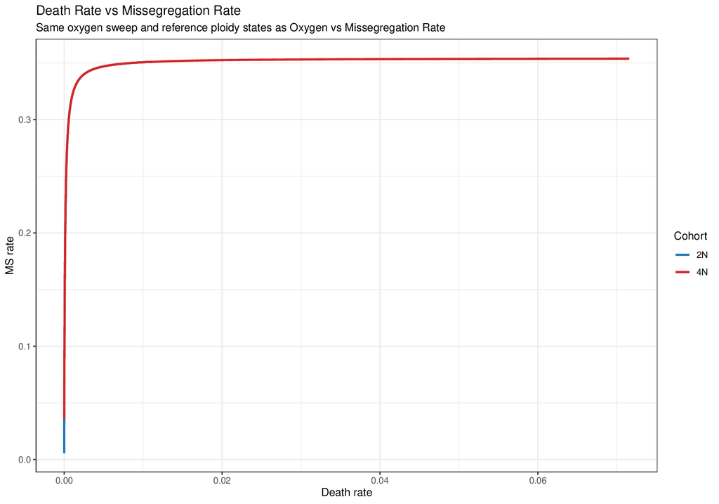

**Figure 3.1.3.2.3 Death Rate vs Missegregation Rate**

Missegregation-rate curve plotted against the fitted death rate at the 2N and 4N reference ploidy states.

##### 3.1.3.3 Coupled-G vs Fixed-G20 O2 and Ploidy Diagnostics

Side-by-side comparisons of original coupled G=O2 diagnostics against fixed G=20 diagnostics.

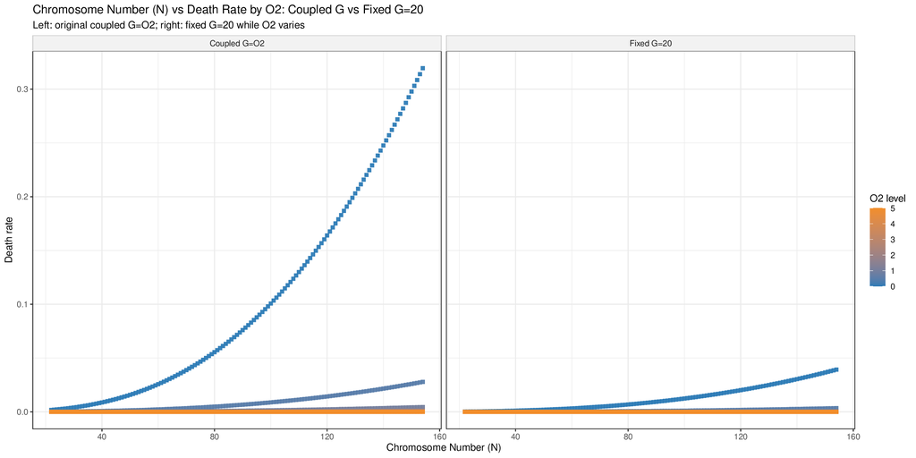

**Figure 3.1.3.3.1 Ploidy vs Death Rate by O2: Coupled G vs Fixed G=20**

Side-by-side comparison of the original coupled G=O2 diagnostic and the fixed-G=20 diagnostic.

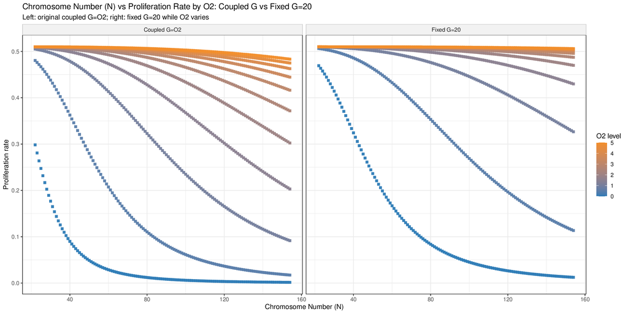

**Figure 3.1.3.3.2 Ploidy vs Proliferation Rate by O2: Coupled G vs Fixed G=20**

Side-by-side comparison of the original coupled G=O2 diagnostic and the fixed-G=20 diagnostic.

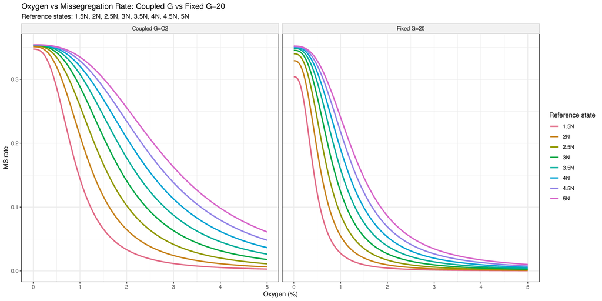

**Figure 3.1.3.3.3 Oxygen vs Missegregation Rate: Coupled G vs Fixed G=20**

Side-by-side comparison of oxygen-response MS curves under coupled G=O2 and fixed G=20.

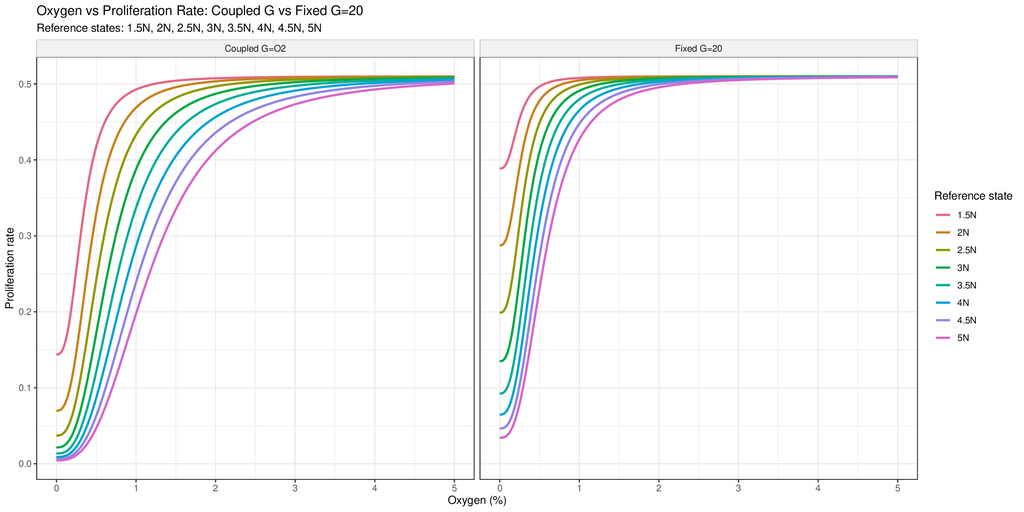

**Figure 3.1.3.3.4 Oxygen vs Proliferation Rate: Coupled G vs Fixed G=20**

Side-by-side comparison of oxygen-response proliferation curves under coupled G=O2 and fixed G=20.

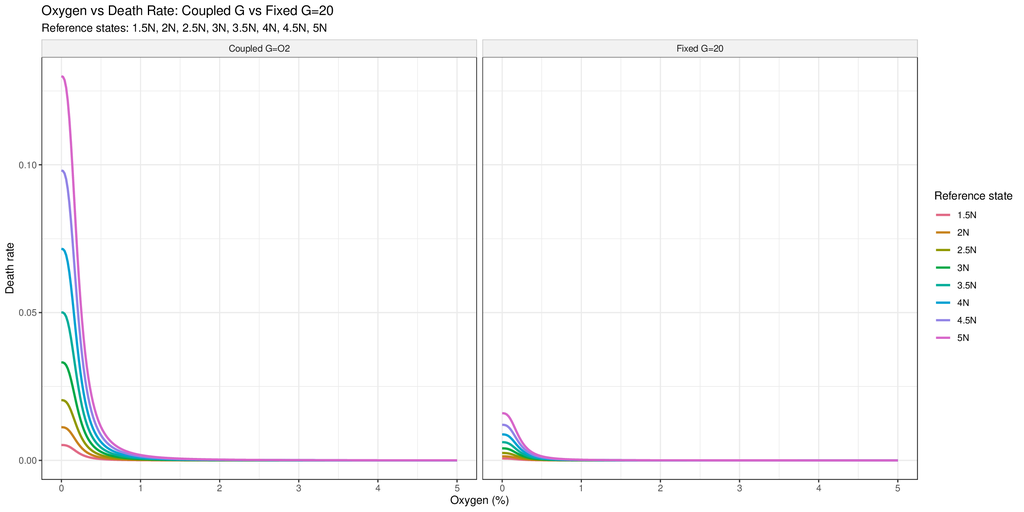

**Figure 3.1.3.3.5 Oxygen vs Death Rate: Coupled G vs Fixed G=20**

Side-by-side comparison of oxygen-response death-rate curves under coupled G=O2 and fixed G=20.

##### 3.1.3.4 G-O2-Ploidy Rate Maps

Paired G-O2 heatmaps for growth, death, and MS rate at 2N and 4N.

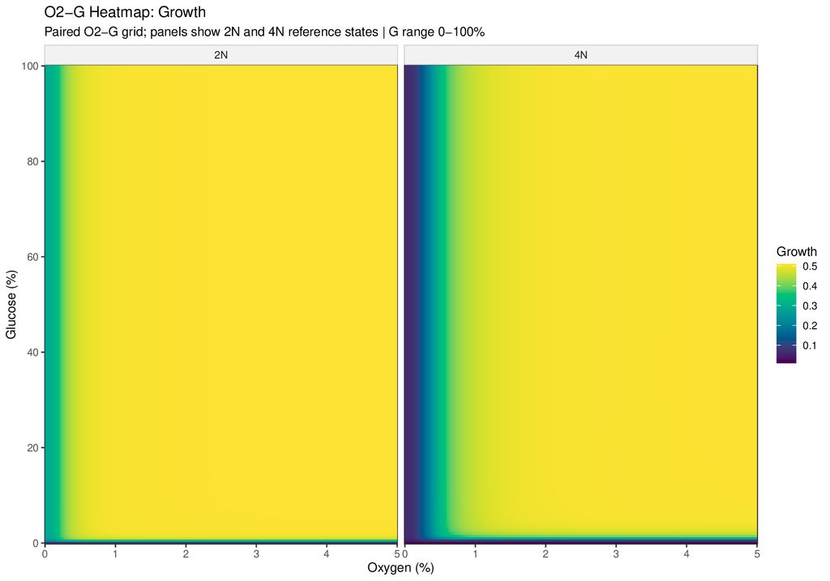

**Figure 3.1.3.4.1 O2-G Heatmap: Growth**

Paired oxygen-glucose grid for fitted proliferation rate; left panel is 2N and right panel is 4N.

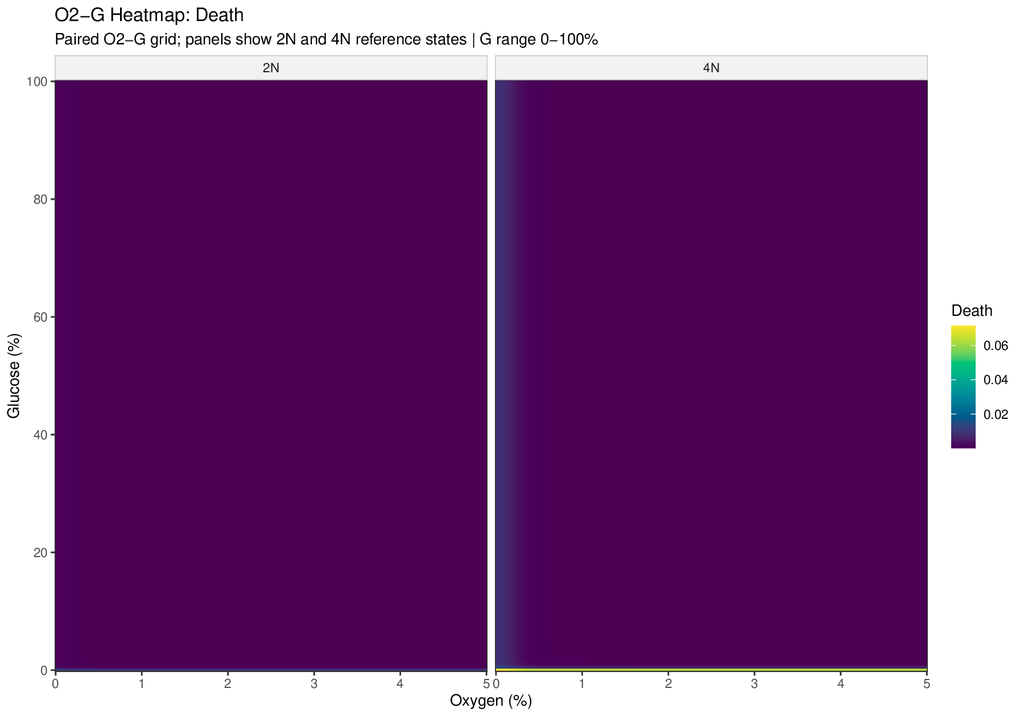

**Figure 3.1.3.4.2 O2-G Heatmap: Death**

Paired oxygen-glucose grid for fitted death rate; left panel is 2N and right panel is 4N.

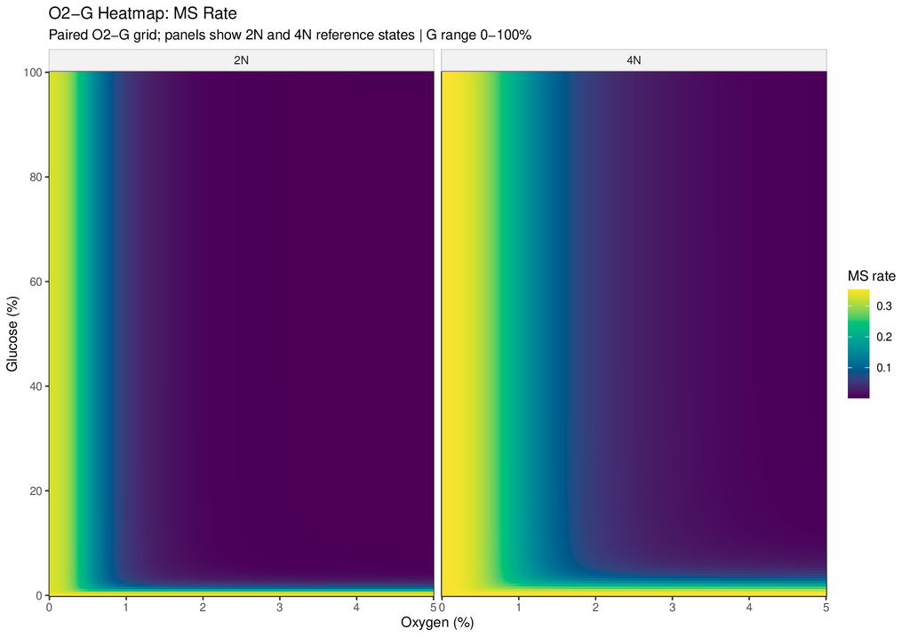

**Figure 3.1.3.4.3 O2-G Heatmap: MS Rate**

Paired oxygen-glucose grid for fitted missegregation rate; left panel is 2N and right panel is 4N.

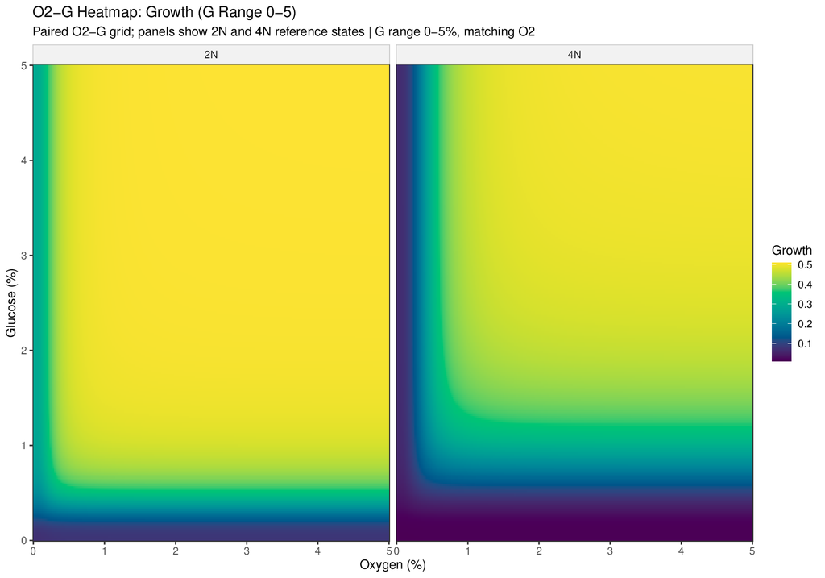

**Figure 3.1.3.4.4 O2-G Heatmap: Growth (G Range 0-5)**

Paired oxygen-glucose grid for fitted proliferation rate with glucose restricted to 0-5%, matching the oxygen range; left panel is 2N and right panel is 4N.

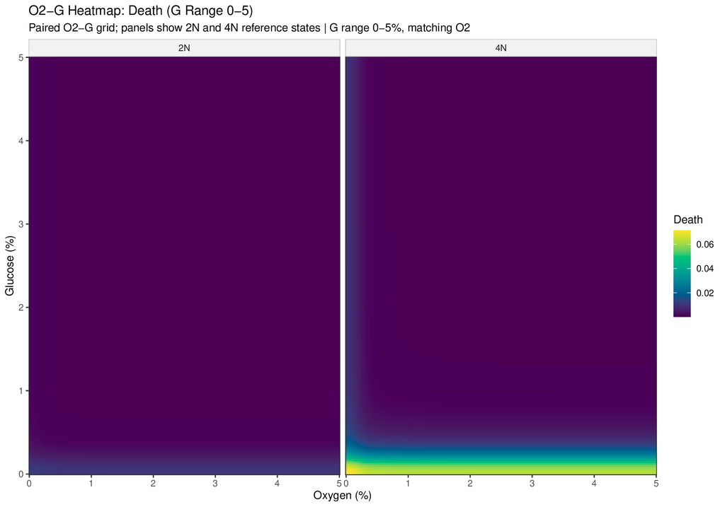

**Figure 3.1.3.4.5 O2-G Heatmap: Death (G Range 0-5)**

Paired oxygen-glucose grid for fitted death rate with glucose restricted to 0-5%, matching the oxygen range; left panel is 2N and right panel is 4N.

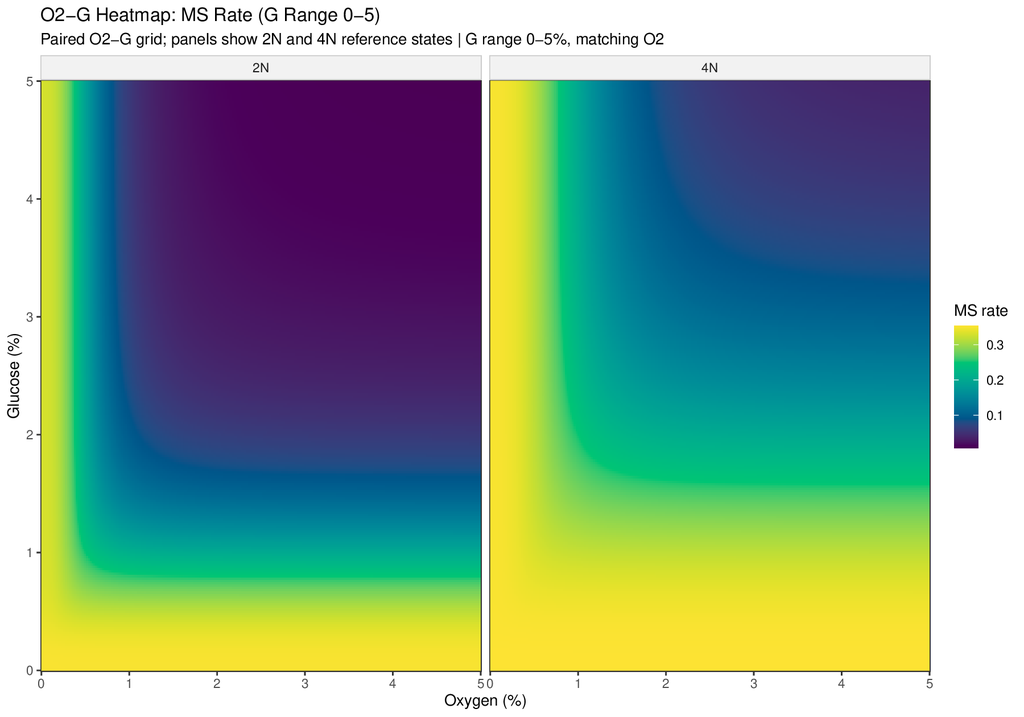

**Figure 3.1.3.4.6 O2-G Heatmap: MS Rate (G Range 0-5)**

Paired oxygen-glucose grid for fitted missegregation rate with glucose restricted to 0-5%, matching the oxygen range; left panel is 2N and right panel is 4N.

### 3.2 In Vitro

#### 3.2.1 Identifiability Diagnostics

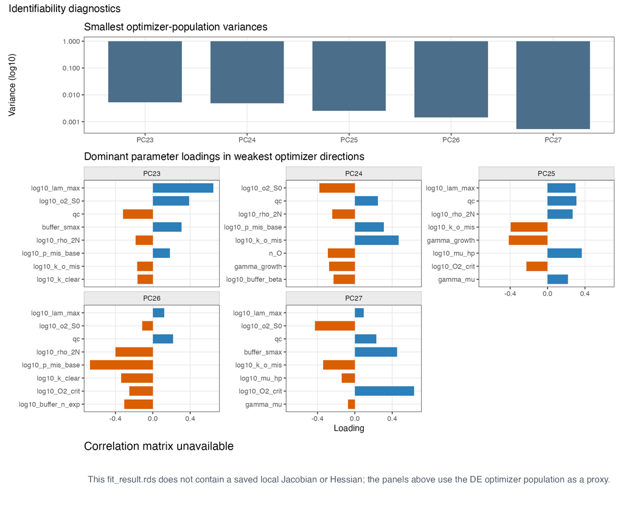

**Figure 3.2.1.1 Identifiability Diagnostics**

Local identifiability output for the current seed when available. If no Jacobian/Hessian was saved, the figure reports an optimizer-population proxy instead.

#### 3.2.2 Rate-Function Diagnostics

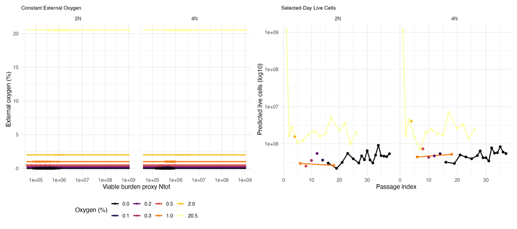

**Figure 3.2.2.1 Constant External Oxygen and Selected-Day Live Cells**

Left panel shows constant external oxygen settings used by the in vitro runner. Right panel shows selected-day predicted live cells. The two panels share the oxygen legend.

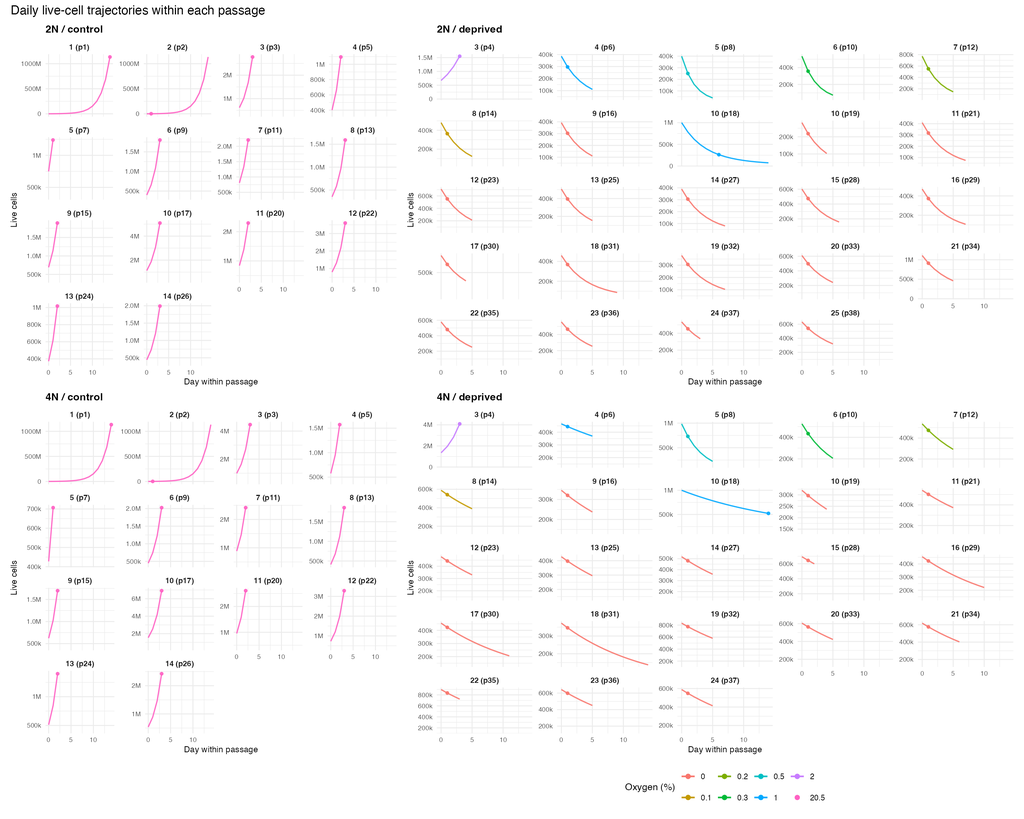

**Figure 3.2.2.2 Daily Live-Cell Trajectories**